# Simple Exploration Techniques for Time Series Analysis

## Intro

What’s a time series anyway ?

*“Is it recorded or produced with temporal information ?”*

frequently encountered in day to day life

- Marketing: Prices, Sales, economic indices
- Central Beauro of Statistics: Demographic information
- Physical: such as Weather history

frequently encountered in research

- Observation Counts: Pop. & community ecology
- Environmental
- recording instrument output

Data fit for classic time series analysis in base R

- The Time Variable/Axis
  - No Missing Values
  - Equidistant
- The Response Variable should be continuous or pseudo continuous

## Goals For today

1. Learn some basic R tools for exploring series
2. Understand and quantify Serial correlation in time
3. Preparation for further analysis

## Why bother ?

- Variables in Time almost always behave differently than in space
- Explaining Observations - Multiple regression models are helpful, but they are not really designed to handle real time-series data
- For Real time series - Sample Summary Statistics (e.g.. Sample Mean and Variance ) are potentially misleading by themselves.
  - They do not have their usual properties
  - we can compute them (also for Time Series Statistics), but to describe populations we better remove systematic components from the samples first.

## Objectives of Time Series Analysis

- Description - what we are here for today
- Explanation
- Predictions, both with and without external variables
- Control
- Detection of anomalies

Let’s load some sample data and examine its structure

```r
blowfly <- read.csv("blowfly.csv", header = T)
blowfly
```

| eggs | nonemerging | emerging | deaths | total |
| --- | --- | --- | --- | --- |
| 0 | 0 | 948 | 0 | 948 |
| 0 | 0 | 4 | 10 | 942 |
| 0 | 0 | 0 | 31 | 911 |
| 0 | 0 | 0 | 53 | 858 |
| 2149 | 121 | 0 | 57 | 801 |
| 4627 | 260 | 0 | 125 | 676 |
| 4523 | 281 | 0 | 172 | 504 |
| 6030 | 458 | 0 | 107 | 397 |
| 2684 | 120 | 0 | 149 | 248 |
| 3373 | 176 | 0 | 102 | 146 |

[output cut: 351 more lines]

Time for a first look at Nicholson’s flies

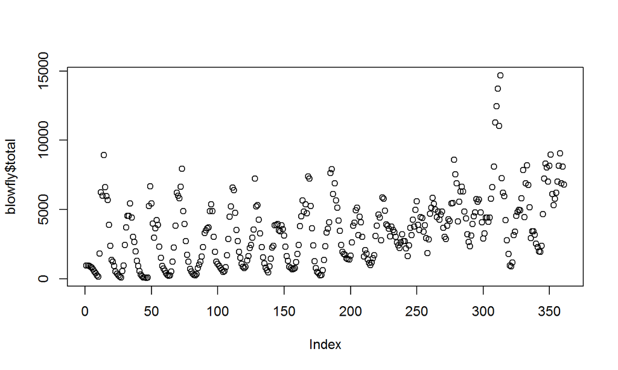

```r
plot(blowfly$total)
```

We can see some patterns already…

and using a time series plotting method:

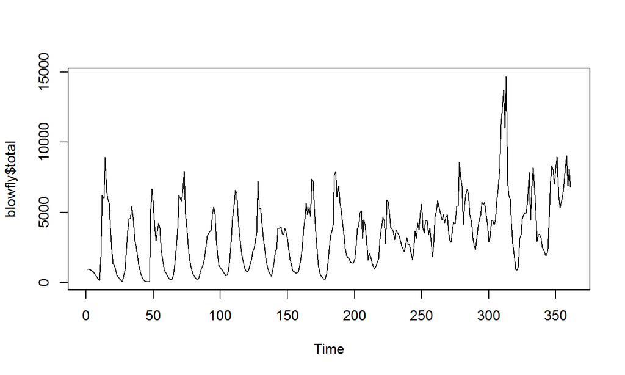

```r
plot.ts(blowfly$total)
```

Multiple Time Series

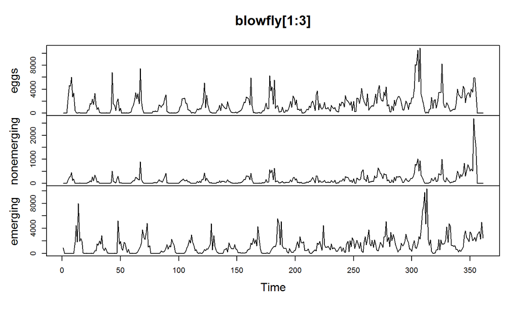

```r
plot.ts(blowfly[1:3])
```

## The `ts` class

`plot.ts` plots the object as if it were of the special class of R objects known simply as *ts*

the `ts()` function is used to convert objects to the ts class

```r
flies <- ts(blowfly$total)
eggs<-ts(blowfly$eggs)

nonemerging<- ts(blowfly$nonemerging)
emerging<- ts(blowfly$emerging)


class(flies)
```

```
## [1] "ts"
```

```r
typeof(flies)
```

```
## [1] "integer"
```

setting the `start`, `end`, and `frequency` parameters and functions

```r
start(flies) ; end(flies) ; frequency(flies)
```

```
## [1] 1 1
```

```
## [1] 361   1
```

```
## [1] 1
```

Add a start year with `start` or `st`

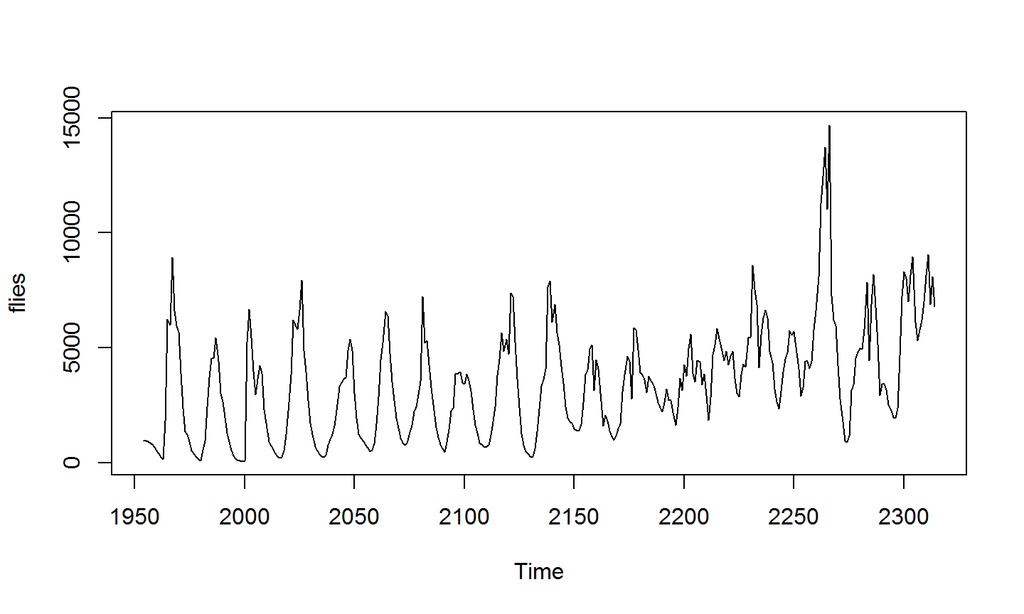

```r
flies<-ts(blowfly$total, start=1954)
plot(flies)
```

```r
print(flies,calendar=T)
```

```
##  1954  1955  1956  1957  1958  1959  1960  1961  1962  1963  1964  1965
##   948   942   911   858   801   676   504   397   248   146  1801  6235
##  1966  1967  1968  1969  1970  1971  1972  1973  1974  1975  1976  1977
##  5974  8921  6610  5973  5673  3875  2361  1352  1226   912   521   363
##  1978  1979  1980  1981  1982  1983  1984  1985  1986  1987  1988  1989
##   229   142    82   542   939  2431  3687  4543  4535  5441  4412  3022
##  1990  1991  1992  1993  1994  1995  1996  1997  1998  1999  2000  2001
##  2656  1967  1295   915   551   313   167    95    93    60    68  5259
##  2002  2003  2004  2005  2006  2007  2008  2009  2010  2011  2012  2013
##  6673  5441  3987  2952  3648  4222  3889  2295  1509   928   739   566
##  2014  2015  2016  2017  2018  2019  2020  2021  2022  2023  2024  2025
##   383   274   192   226   519  1224  2236  3818  6208  5996  5789  6652
##  2026  2027  2028  2029  2030  2031  2032  2033  2034  2035  2036  2037
##  7939  4868  3952  2712  1734  1224   703   508   366   279   243   343
##  2038  2039  2040  2041  2042  2043  2044  2045  2046  2047  2048  2049
```

[output cut: 47 more lines]

Set time units and frequency with `start` and `frequency` the frequency will be the number of columns

example: set a quarterly frequency

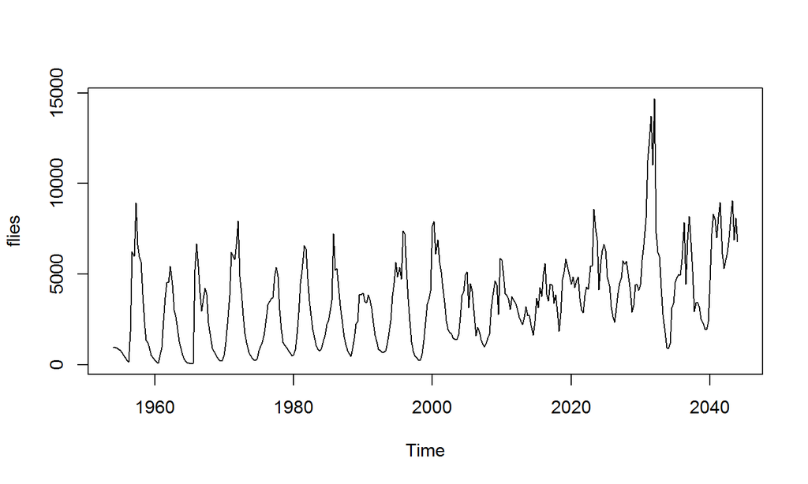

```r
flies<-ts(blowfly$total, start=c(1954,1),frequency = 4)
plot(flies)
```

```r
print(flies,calendar=T)
```

```
##       Qtr1  Qtr2  Qtr3  Qtr4
## 1954   948   942   911   858
## 1955   801   676   504   397
## 1956   248   146  1801  6235
## 1957  5974  8921  6610  5973
## 1958  5673  3875  2361  1352
## 1959  1226   912   521   363
## 1960   229   142    82   542
## 1961   939  2431  3687  4543
## 1962  4535  5441  4412  3022
## 1963  2656  1967  1295   915
## 1964   551   313   167    95
## 1965    93    60    68  5259
## 1966  6673  5441  3987  2952
## 1967  3648  4222  3889  2295
```

[output cut: 77 more lines]

set a monthly frequency

```r
flies<-ts(blowfly$total, start=c(1954,1), frequency = 12)
print(flies,calendar=T)
```

```
##        Jan   Feb   Mar   Apr   May   Jun   Jul   Aug   Sep   Oct   Nov
## 1954   948   942   911   858   801   676   504   397   248   146  1801
## 1955  5974  8921  6610  5973  5673  3875  2361  1352  1226   912   521
## 1956   229   142    82   542   939  2431  3687  4543  4535  5441  4412
## 1957  2656  1967  1295   915   551   313   167    95    93    60    68
## 1958  6673  5441  3987  2952  3648  4222  3889  2295  1509   928   739
## 1959   383   274   192   226   519  1224  2236  3818  6208  5996  5789
## 1960  7939  4868  3952  2712  1734  1224   703   508   366   279   243
## 1961   761  1025  1221  1600  2267  3290  3471  3637  3703  4876  5364
## 1962  3029  1950  1225  1076   905   772   628   473   539   825  1702
## 1963  4473  5221  6592  6400  4752  3521  2719  1931  1500  1082   849
## 1964   864  1308  1624  2224  2423  2959  3547  7237  5218  5311  4273
## 1965  2281  1549  1091   796   610   445   894  1454  2262  2363  3847
## 1966  3935  3479  3415  3861  3571  3113  2319  1630  1297   861   761
## 1967   701   762  1188  1778  2428  3806  4519  5646  4851  5374  4713
```

[output cut: 49 more lines]

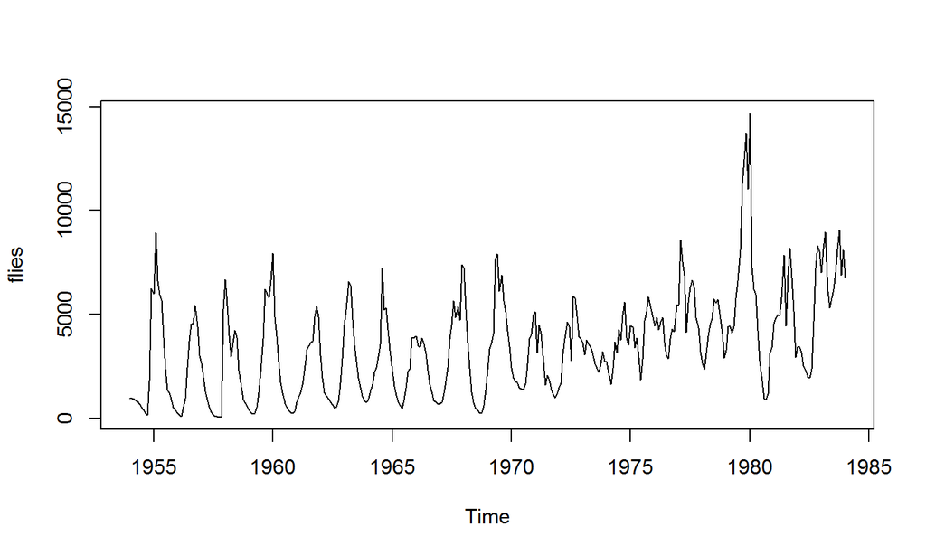

```r
plot(flies)
```

explore different persepctives according to frequency with `aggregate` and `boxplot`

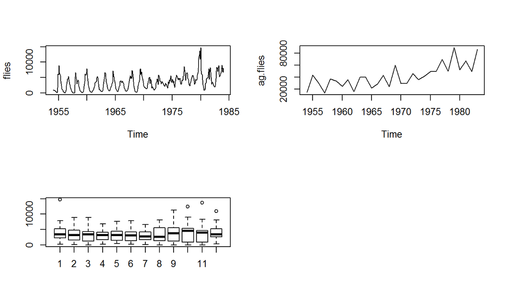

```r
par(mfrow=c(2,2))
plot(flies)
ag.flies<-aggregate(flies) ; plot(ag.flies)
cyc.flies<- cycle(flies) ; boxplot(flies ~ cyc.flies)
par(mfrow=c(1,1))
```

`cycle` was used to pull up the monthly interval as a categorical variable

Draw 2 series that have the same time axis together, with `cbind`

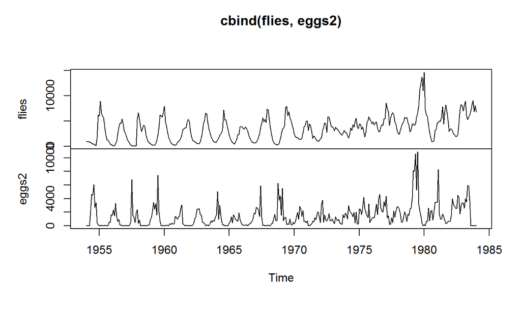

```r
eggs2<-ts(blowfly$eggs, start=c(1954,1), frequency = 12)
plot(cbind(flies , eggs2 ))
```

set a frequency of every 2-3 days

```r
flies<-ts(blowfly$total, start=(c(1954,1)) , freq = 150)
print(flies,calendar=T)
```

```
##         p1    p2    p3    p4    p5    p6    p7    p8    p9   p10   p11
## 1954   948   942   911   858   801   676   504   397   248   146  1801
## 1955  2319  1630  1297   861   761   659   701   762  1188  1778  2428
## 1956  3270  4404  4398  4112  4401  5779  6597  8091 11282 12446 13712
##        p12   p13   p14   p15   p16   p17   p18   p19   p20   p21   p22
## 1954  6235  5974  8921  6610  5973  5673  3875  2361  1352  1226   912
## 1955  3806  4519  5646  4851  5374  4713  7367  7236  5245  3636  2417
## 1956 11017 14683  7258  6195  5962  4213  2775  1781   936   898  1160
##        p23   p24   p25   p26   p27   p28   p29   p30   p31   p32   p33
## 1954   521   363   229   142    82   542   939  2431  3687  4543  4535
## 1955  1258   766   479   402   248   254   604  1346  2342  3328  3599
## 1956  3158  3386  4547  4823  4970  4940  5793  7836  4457  6901  8191
##        p34   p35   p36   p37   p38   p39   p40   p41   p42   p43   p44
## 1954  5441  4412  3022  2656  1967  1295   915   551   313   167    95
## 1955  4081  7643  7919  6098  6896  5634  5134  4188  3469  2442  1931
## 1956  6766  5165  2919  3415  3431  3162  2525  2290  1955  1936  2384
##        p45   p46   p47   p48   p49   p50   p51   p52   p53   p54   p55
## 1954    93    60    68  5259  6673  5441  3987  2952  3648  4222  3889
## 1955  1790  1722  1488  1416  1369  1666  2627  3840  4044  4929  5111
## 1956  4666  7219  8306  8027  7010  8149  8949  6105  5324  5766  6214
##        p56   p57   p58   p59   p60   p61   p62   p63   p64   p65   p66
## 1954  2295  1509   928   739   566   383   274   192   226   519  1224
## 1955  3152  4462  4082  3026  1589  2075  1829  1388  1149   968  1170
## 1956  7007  8154  9049  6883  8103  6803
##        p67   p68   p69   p70   p71   p72   p73   p74   p75   p76   p77
## 1954  2236  3818  6208  5996  5789  6652  7939  4868  3952  2712  1734
## 1955  1465  1676  3075  3815  4639  4424  2784  5860  5781  4897  3920
## 1956
##        p78   p79   p80   p81   p82   p83   p84   p85   p86   p87   p88
## 1954  1224   703   508   366   279   243   343   761  1025  1221  1600
## 1955  3835  3618  3050  3772  3517  3350  3018  2625  2412  2221  2619
## 1956
##        p89   p90   p91   p92   p93   p94   p95   p96   p97   p98   p99
## 1954  2267  3290  3471  3637  3703  4876  5364  4890  3029  1950  1225
## 1955  3203  2706  2717  2175  1628  2388  3677  3156  4272  3771  4955
## 1956
##       p100  p101  p102  p103  p104  p105  p106  p107  p108  p109  p110
## 1954  1076   905   772   628   473   539   825  1702  2868  4473  5221
## 1955  5584  3891  3501  4436  4369  3394  3869  2922  1843  2837  4690
## 1956
##       p111  p112  p113  p114  p115  p116  p117  p118  p119  p120  p121
## 1954  6592  6400  4752  3521  2719  1931  1500  1082   849   774   864
## 1955  5119  5839  5389  4993  4446  4851  4243  4620  4849  3664  3016
## 1956
##       p122  p123  p124  p125  p126  p127  p128  p129  p130  p131  p132
## 1954  1308  1624  2224  2423  2959  3547  7237  5218  5311  4273  3270
## 1955  2881  3821  4300  4168  5446  5477  8579  7533  6884  4127  5546
## 1956
##       p133  p134  p135  p136  p137  p138  p139  p140  p141  p142  p143
## 1954  2281  1549  1091   796   610   445   894  1454  2262  2363  3847
## 1955  6313  6650  6304  4842  4352  3215  2652  2330  3123  3955  4494
## 1956
##       p144  p145  p146  p147  p148  p149  p150
## 1954  3876  3935  3479  3415  3861  3571  3113
## 1955  4780  5753  5555  5712  4786  4066  2891
## 1956
```

```r
plot(flies)
```

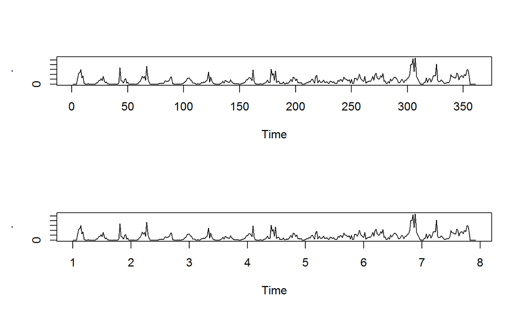

```r
par(mfrow=c(2,1))
blowfly$eggs %>% ts(frequency= 1) %>% plot
blowfly$eggs %>% ts(frequency= 52) %>% plot
```

```r
par(mfrow=c(1,1))
```

the ‘ts’ class allows R to understand

- that a vector is based on a uni-directional time sequence
- convert frequencies easily

many base/stats functions are actually designed for the ‘ts’ class

but using them on a non- *ts* object may or may not result in an error

Warning: the `ts` class is designed only for equidistant series. other packages have other classes and functions which extend capabilities

## Time series exploration & Descriptive techniques

- relatively clear cyclical process, at least at the beginning (points 1:200).
- the second part (200:361) looks less regular and with an upward trend.

## Exploratory Questions

- what are the cycle periods ?
- is there any hidden periodical behaviour that is not immediately apparent ?
- Do these 2 parts behave similarly or is there a fundamental change ? which attributes of the first part are conserved in the second part

We can see some clearer cyclical behaviour of a section if we zoom in and explore a bit with `window`:

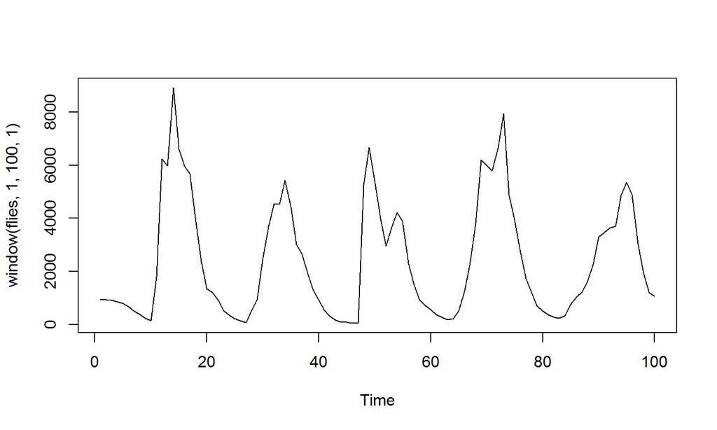

```r
flies<-ts(blowfly$total)
plot(window(flies, 1, 100, 1))
```

more zooming with `deltat`:

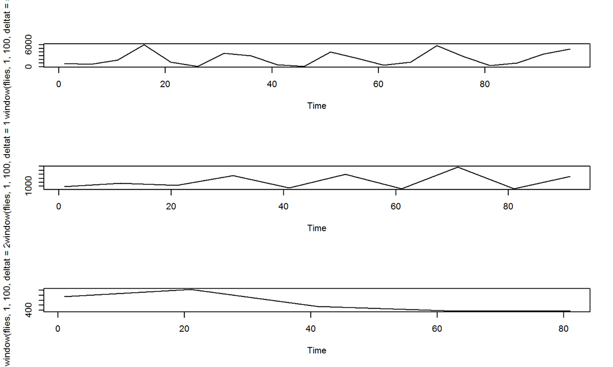

```r
par(mfrow=c(3,1))
plot(window(flies, 1, 100, deltat = 5))
plot(window(flies, 1, 100, deltat = 10))
plot(window(flies, 1, 100, deltat = 20))
```

```r
par(mfrow=c(1,1))
```

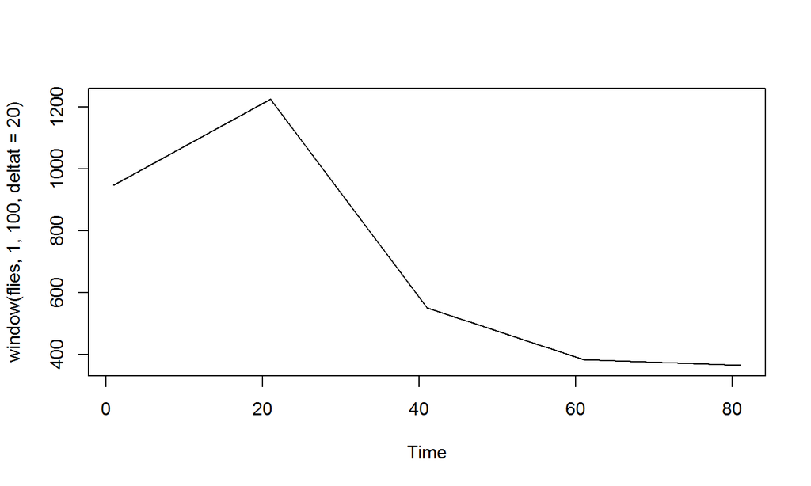

```r
plot(window(flies, 1, 100, deltat = 20))
```

We finally lose the cyclical behaviour at ~`deltat=20`. let’s remember this…

The flies series is unusually clear, and still - its cyclical behaviour is only one possible pattern.

other series may represent processes that behave in a way that is not immediately recognizable, and have many things going at once.

examples

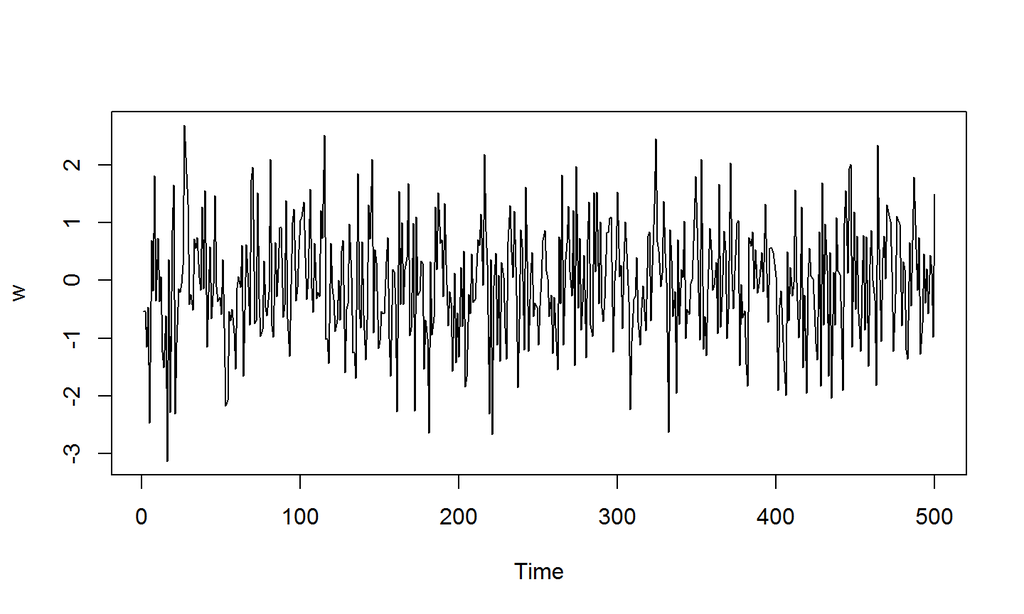

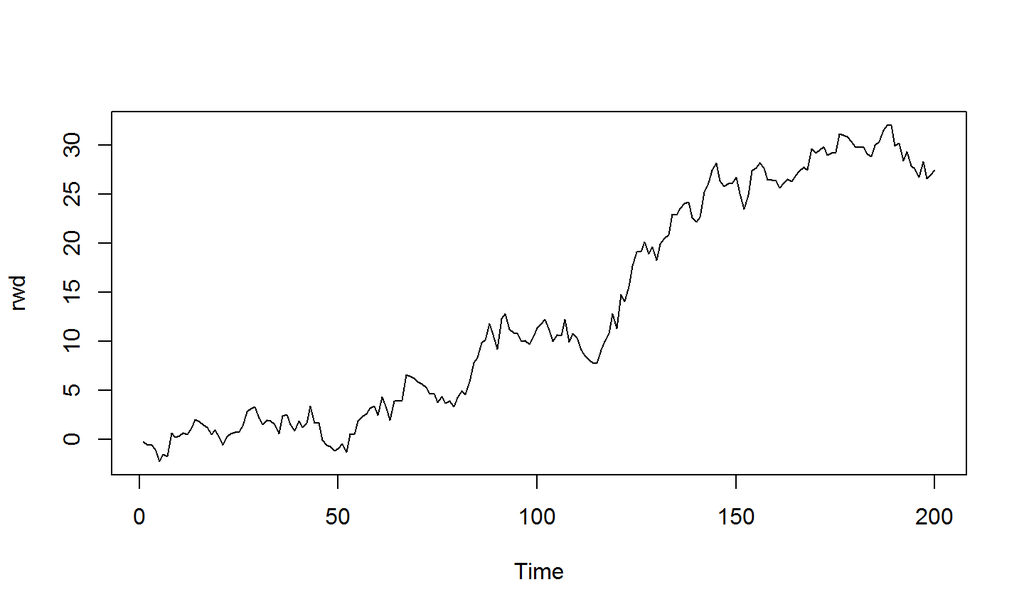

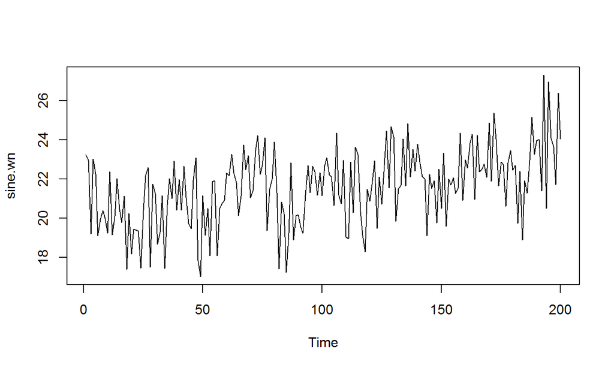

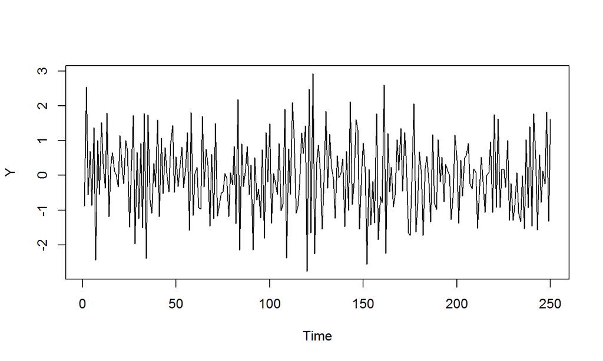

We naturally want tools that will describe the entire series’ and parts of the series’ attributes, be executable fast in R, and guide us in further steps (such as model fitting and forecasting).

for that, we need to understand how a given series evolves through time - via autocorrelation and related attributes of time series

## Measures of serial dependence

The Lag Plot

Auto-correlation

Partial Auto-correlation

Cross-Correlation

### Background on Autocorrelation - The lag plot.

how does my data behave in relation to itself ? or ’how does this week’s population relate to last week’s population ?

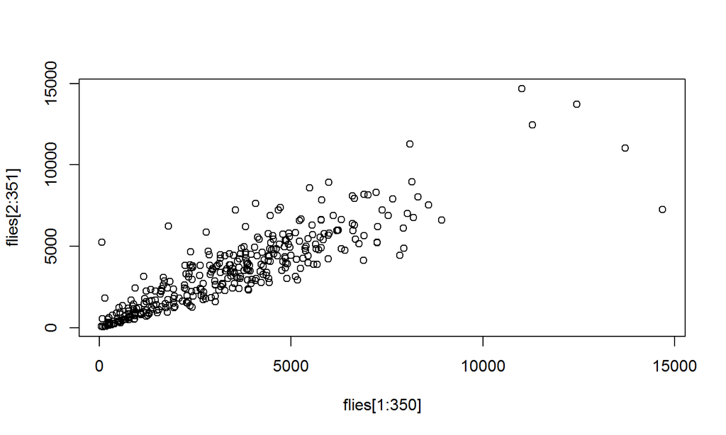

```r
plot(flies[1:350], flies[2:351])
```

Clearly, there’s a pattern at lag =1, at least in the smaller population sizes

now let’s look at lags 2 and 3:

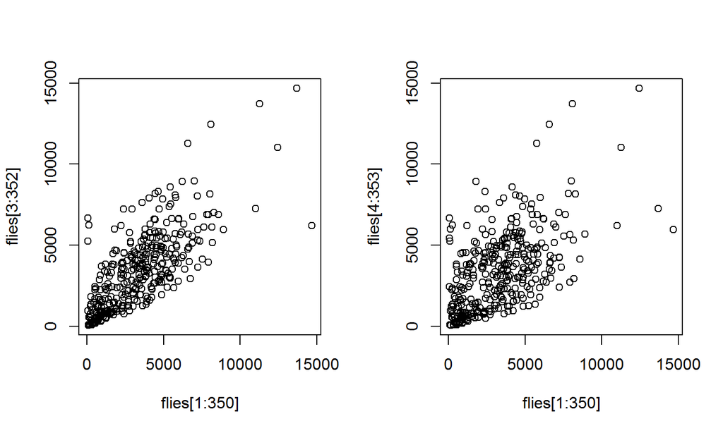

```r
par(mfrow=c(1,2))
plot(flies[1:350], flies[3:352])
plot(flies[1:350], flies[4:353])
par(mfrow=c(1,1))
```

we start losing the pattern gradually, as we go to higher lags…

more lags, lag = 1 to lag =8, using `lag.plot()`

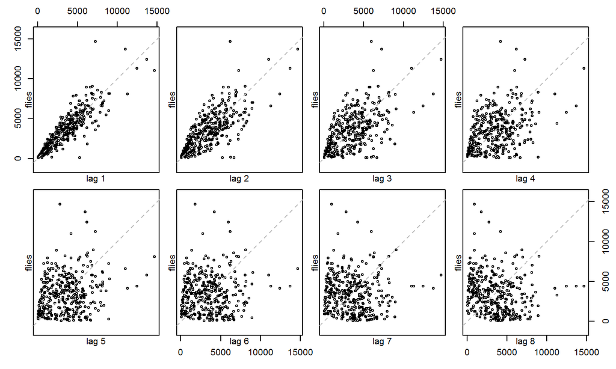

```r
lag.plot(flies, lag = 8, layout = c(2, 4), diag = T)
```

however, at lags 9-16:

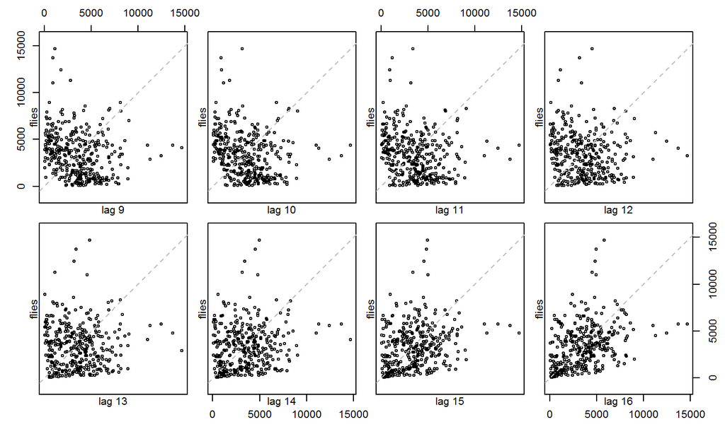

```r
lag.plot(flies, lags = 8, set.lags = 9:16, layout = c(2, 4), diag = T)
```

**summary**

- we begin with a pattern, lose it, and then find it again
- at smaller populations, we begin with a positive correlation, lose it, then a negative correlation which peaks at about lag = 10, lose it, and so the cycle goes.

### The Correlogram, using `acf()`

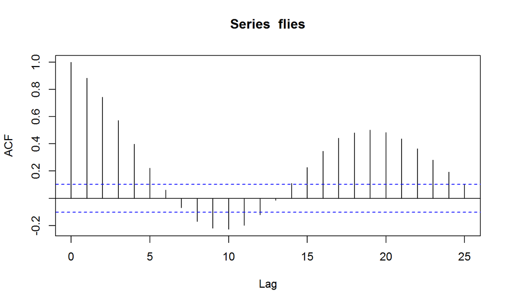

```r
acf(flies)
```

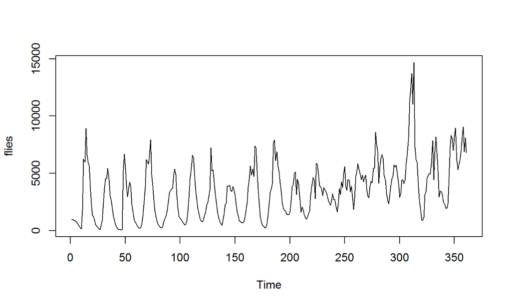

```r
plot(flies)
```

This summarizes and charts the autocorrelation structure in the series, up to a default lag size, which is 25 in this case.

The vertical axis is the magnitude of the **Sample Autocorrelation Coefficients**. they measure the relative correlation between observations at different distances apart (lags)

and the horizontal axis is simply the lag size.

let’s have a look at these **Sample Autocorrelation Coefficients**

```r
a <- acf(flies, plot = F)
```

```r
a$acf %>% head(10) # for the actual factors
```

```
##  [1]  1.00000000  0.88266919  0.74218182  0.57299028  0.39789881
##  [6]  0.22191632  0.06209902 -0.06770406 -0.16982318 -0.21847342
```

there’s no better evidence of cycles, the flies exhibit strong positive AND negative correlation at regular intervals throughout the series, with a cycle period of 19 weeks.

[figure not shown]

let’s look at the entire series

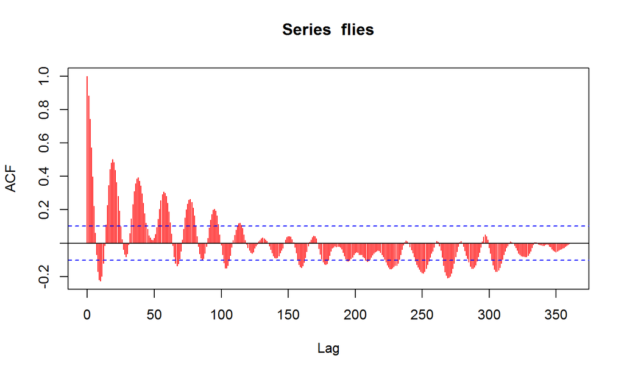

```r
acf(flies, lag.max = 360, col = "red")
```

We can see

- the (sort of regular) cyclical pattern, especially at the beginning
- the diminishing positive correlation
- some alternation between positive and negative correlations, which is typical of cycles.

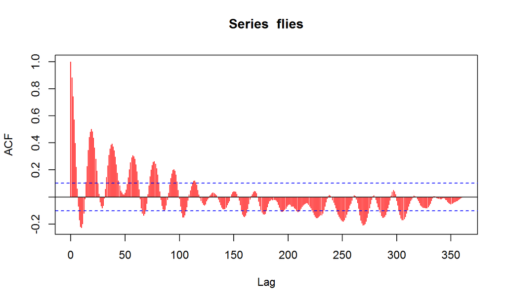

```r
acf(flies, lag.max = 360, col = "red")
```

warning: there is bias here with increasing lag size. why ?

- there’s some kind of a diminishing but long term “memory” in the system, up to a lag of 100 weeks.
  - events that happened 50 weeks ago may still have an influence.
- clear cycles with a period of 19 weeks

The main point :there’s a **LOT** of non-randomness in the sequence

This last point is especially important for linear and other modelling, which assume that samples are independent. we may want to stop and think before going on to perform a conventional `lm()` ! , and at the very least be aware of series’ behaviour.

and this illustrates why we need to explore time series internally before we go on to the other, external parameters.

The **Sample Auto-covariance Coefficients**

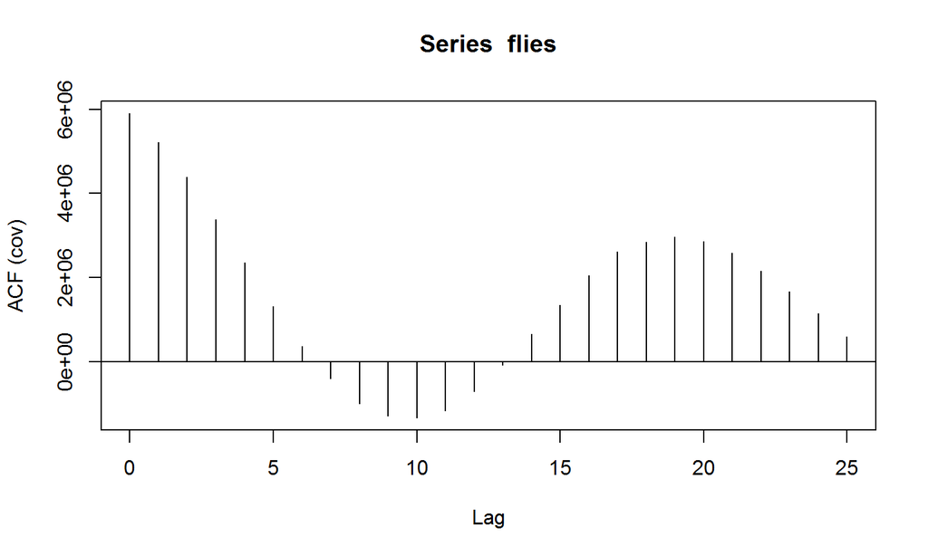

```r
acf(flies, type = "covariance")
```

```r
acf(flies, type = "covariance", plot = F)$acf %>% head(10)
```

```
##  [1]  5908371.3  5215137.3  4385085.8  3385439.3  2350933.9  1311164.0
##  [7]   366904.1  -400020.7 -1003378.4 -1290822.1
```

### Partial Autocorrelation

Correlograms produced using the sample *autocorrelation* coefficients do not account for the fact that for a given lag size there may be correlation between internal points, (e.g.. values that are 4 points apart were correlated, but so do values that are 2 points apart).

We sometimes want to control for the internal correlations inside the lag, or in other words, to check what would have been the correlation coefficients, had all the internal lags’ coefficients were forced to zero.

This helps us later on, when selecting a model

the **Partial Autocorrelation** is the relationship between this week’s population and the population at lag n when we have already controlled for the correlations between all of the successive weeks between this week and week n

We only need to use `pacf` or `acf(type="partial")` instead of the default

```r
acc <- a$acf %>% head(12) %>% round(2)

partial.acc <- pacf(flies, plot = F) %>% .$acf %>% head(12) %>% round(2)

acc
```

```
##  [1]  1.00  0.88  0.74  0.57  0.40  0.22  0.06 -0.07 -0.17 -0.22 -0.23
## [12] -0.20
```

```r
partial.acc
```

```
##  [1]  0.88 -0.17 -0.21 -0.12 -0.12 -0.06 -0.01 -0.03  0.09  0.05  0.04
## [12]  0.16
```

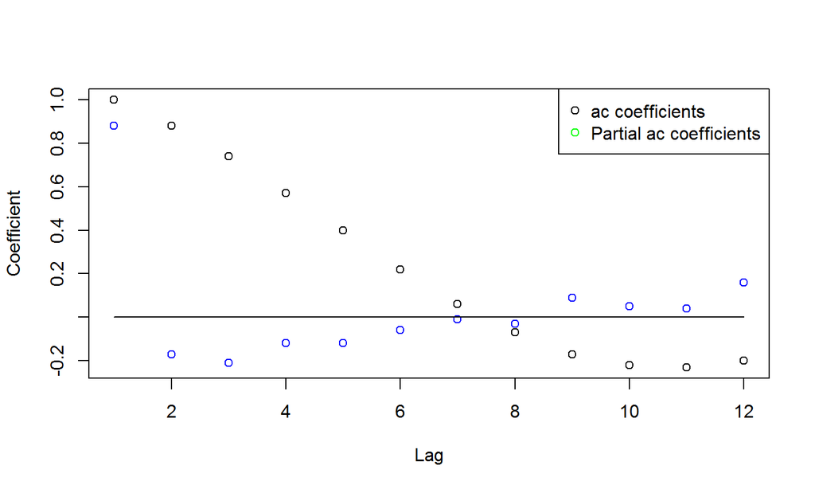

```r
plot(1:12, acc, xlab = "Lag", ylab = "Coefficient")
points(1:12, partial.acc, col = "blue")
lines(1:12, rep(0, 12))
legend("topright", c("ac coefficients", "Partial ac coefficients"), col = c("black", "green"), pch = c(1, 1))
```

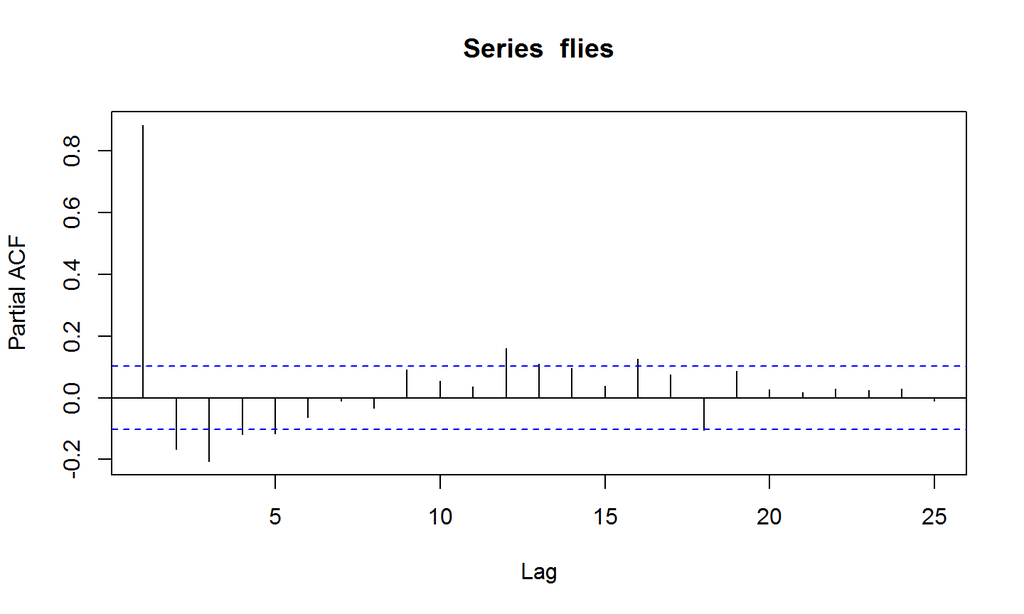

```r
pacf(flies)
```

what can we take from this ?

- the maximal negative and maximal positive lags are important places in the cycle.
- clues for possible underlying processes in lags 3 and 12

the PACF can be thought of as analogous to a derivative of ACF - thus finding points driving change in pitch or direction.

Summary till now, using just Correlograms for the entire series

- cycle length - about 19
- Lags 2-4, 12-16 are suspected: we should look for biological mechanisms there, when we construct an explanatory model.
- Note: these are clues generated only from the time series itself, before considering any other data or knowledge in biology

### Cross Correlation

The total number of flies is not the only one we have…

we could always scatter-plot the data frame variables against each other

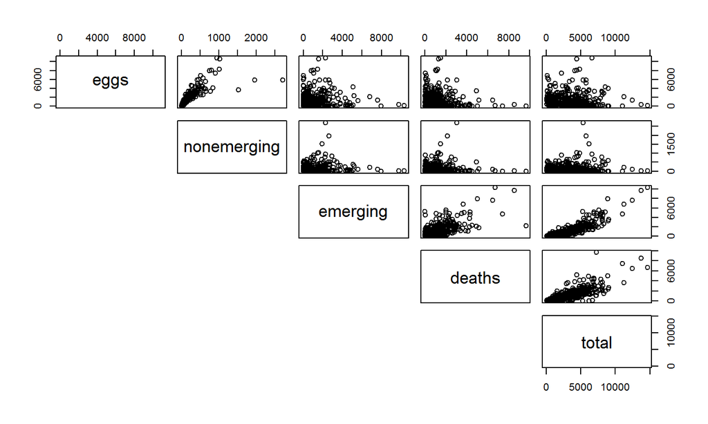

```r
plot(blowfly, lower.panel = NULL)
```

we get a strong correlation between total, deaths, and emerging. but there’s an inherent problem in this analysis…

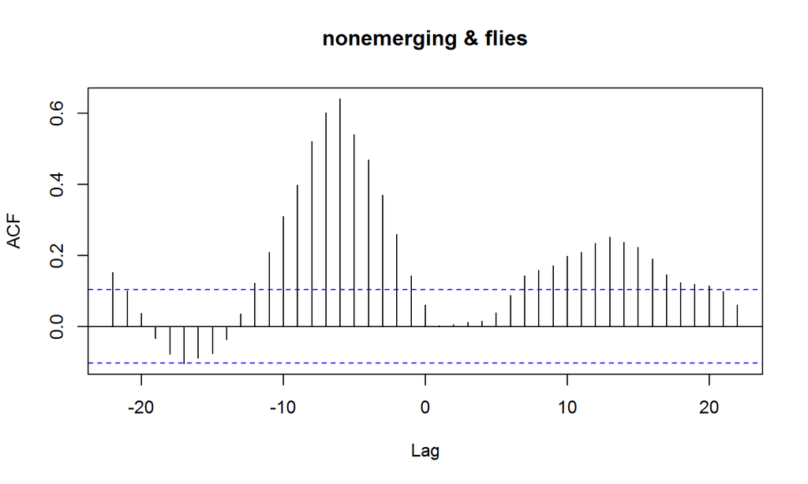

```r
flies <- ts(blowfly$total)

ccf(nonemerging, flies)
```

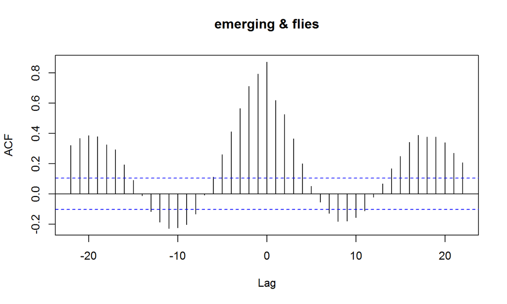

```r
ccf(emerging, flies)
```

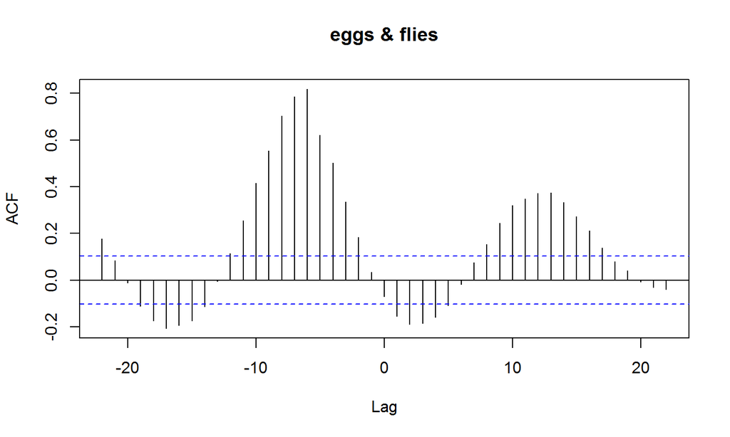

```r
ccf(eggs, flies)
```

Reminder: Lags 2-4 (negative), 12-16 (positive) are suspected from `pacf()` of the total of “flies”

from `ccf()`

example, eggs vs. total-

- negative at lags 2-3
- negative at (-17 - -16)
- positive at 12-13

it can be difficult to construct an explanation from this alone, but at least we now have clues of lead times and delay times between every two variables.

This is a first step in time series stats, towards modelling.

findings: cycle length = still 19

one possible explanation: larval processes *appear* to drive the cycles when they reach a maximum (density dependent competition ?)